# GENESIS Bug Demo

Max Segnitz

2/18/2022

# Reproduce GENESIS bug with confounding covariate.

Reproduce a bug encountered in GENESIS. We found that when a model covariate (in our case “sex”) was fully confounded with a SNP genotype, GENSIS returns a highly significant result despite no true association. This is likely only encountered when sample sizes are small and snp-variable counfounding occur by chance.

Here, we reproduce the error using sample data available in the **SNPRelate** package.

```r
# Load libraries
library(tidyverse)
library(gdsfmt)
library(GENESIS)
library(GWASTools)
library(SNPRelate)
library(kableExtra)
library(scales)
library(ggbeeswarm)
library(ggrepel)
```

## Format Sample Data

### Load sample data and randomly subset individuals

Use sample data from **SNPRelate** and randomly subsample to 150 individuals.

```r
# Ensure any GDS links are closed
showfile.gds(closeall=TRUE)

# Open filelink to GDS genotype data
snp_gds <- GdsGenotypeReader(filename = snpgdsExampleFileName())
```

The example data includes 279 individuals and 9088 SNPs.

## Randomly subset individuals

Randomly subset the indivuals in the GDS to a sample size of 150.

```r
# Randomly subset individuals
set.seed(32)
id_subset<-sample(getScanID(snp_gds), size = 150)
```

## Create corresponding .gds

Subset GDS to randomly sampled individuals.

```r
# Ensure any GDS links are closed
showfile.gds(closeall=TRUE)
```

```
##                                                                    FileName
## 1 /Users/maxsegnitz/Library/R/4.0/library/SNPRelate/extdata/hapmap_geno.gds
##   ReadOnly  State
## 1     TRUE closed
```

```r
# Temporarily Subset GDS to PIDs in condition subset
gdsSubset(parent.gds = snpgdsExampleFileName(),
          sub.gds = "data/sample_subset.gds",
          sample.include = id_subset) # filter to relevent samples
```

```
## working on genotype
```

```
## genotype - block 1 of 2
```

```
## genotype - block 2 of 2
```

```
## Clean up the fragments of GDS file:
##     open the file 'data/sample_subset.gds' (401.4K)
##     # of fragments: 31
##     save to 'data/sample_subset.gds.tmp'
##     rename 'data/sample_subset.gds.tmp' (401.2K, reduced: 192B)
##     # of fragments: 15
```

```r
# Open filelink to GDS genotype data
snp_gds_sub <- GdsGenotypeReader(filename =  "data/sample_subset.gds")
```

## Create dummy phenotype & metadata

Create a simulated phenotype against which to test SNP association.

```r
# Create Dummy Data with Modest Effect
set.seed(28)

pheno_meta<-
  data.frame(scanID = id_subset,
             phenotype = rnorm(150, mean = 150, sd = 50))
```

## Randomly select SNP for confounding effect

Randomly select a SNP with only 2 genotypes & create a perfectly confounded dummy covariate.

```r
# create function to randomly select SNP with right properties
random_selection<-
  function(gds){
              success<-FALSE
              while(!success){ # Run loop to randomly generate snp until conditions are met
              rand_snp_index<-sample(1:length(getSnpID(gds)), size=1)
              rand_genotype<- getGenotype(gds)[rand_snp_index,]
              success<-length(unique(rand_genotype[which(!is.na(rand_genotype))]))==2 & sum(rand_genotype, na.rm = T)>=10 # only select snp if there are only 2 genotypes & enough uncommon present
                      }
              rand_snp<-getSnpID(gds)[rand_snp_index]
              return(list(snp=rand_snp, geno = rand_genotype))
              }

# Randomly generate SNP
set.seed(32)
snp_random<-random_selection(snp_gds_sub)

# Pair with PIDs
snp_random_ids<-
  data.frame(scanID=getScanID(snp_gds_sub), snp=snp_random$snp, genotype=snp_random$geno)
```

Create dummy covariate confounded with SNP.

```r
pheno_meta_dummy<-
  inner_join(pheno_meta, snp_random_ids)%>%
  mutate(cov_dummy = as.numeric(as.factor(genotype)))%>%
  mutate(cov_dummy = factor(case_when(cov_dummy==1 ~ "A", cov_dummy ==2 ~ "B"), levels=c("A", "B")))
```

Plot effect by genotype, showing dummy grouping.

The snp shows no association to phenotype.

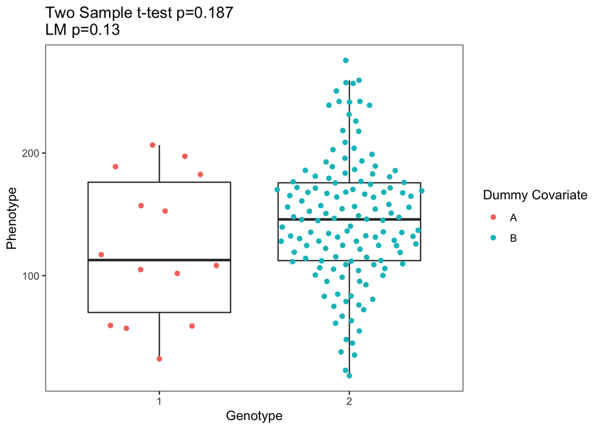

```r
# test for dummy variable effect using t-test and linear model

dummy_ttest<-t.test(phenotype~cov_dummy, data = pheno_meta_dummy)

dummy_lm<-lm(phenotype ~ cov_dummy, data = pheno_meta_dummy)

pheno_meta_dummy%>%
  ggplot(aes(x=as.factor(genotype), y=phenotype))+
  geom_boxplot(outlier.shape = NA, fill=NA)+
  ggbeeswarm::geom_quasirandom(aes(color=cov_dummy))+
  labs(color="Dummy Covariate")+
  ggtitle(paste0("Two Sample t-test p=", round(dummy_ttest$p.value, 3),
                "\nLM p=", round(summary(dummy_lm)$coefficients[2,4], 3)))+
  xlab("Genotype")+
  ylab("Phenotype")+
  theme_bw()+
  theme(panel.grid = element_blank())
```

# Run GWAS

Run association tests of SNPs to phenotype using GENESIS.

```r
# Ensure any GDS links are closed
showfile.gds(closeall=TRUE)
```

```
##                                                                                       FileName
## 1 /Users/maxsegnitz/Documents/WORK/PERSONAL/Github/GENESIS_troubleshoot/data/sample_subset.gds
##   ReadOnly  State
## 1     TRUE closed
```

```r
# Open filelink to GDS genotype data
snp_gds_sub <- GdsGenotypeReader(filename =  "data/sample_subset.gds")

# Format Phenotypes as ScanAnnotation
pheno_dat<-
  pheno_meta_dummy%>%
  arrange(match(scanID, getScanID(snp_gds_sub)))%>% # match scan order to GDS
  ScanAnnotationDataFrame() # Convert to Scan Annotation format


# Format GDS as GenotypeData
snp_genoData <- GenotypeData(snp_gds_sub, scanAnnot = pheno_dat)


###############################
##
##         RUN GWAS
##
################################

#------------------
# Fit Null Model
#------------------

# Covariates = PCs 1-5
nullmod <-
  fitNullModel(pheno_dat,
               outcome = "phenotype",
               covars = c("cov_dummy"),
               cov.mat = NULL, family = "gaussian")

# Check that dummy covariate is not significant & is as expected
nullmod$fixef%>%
  kable(caption = "GENSIS Null Model Covariate Fit")%>%
  kable_styling(bootstrap_options = "striped", full_width =F)
```

GENSIS Null Model Covariate Fit

|  | Estimate | Std. Error | t value | Pr(>\|t\|) |
| --- | --- | --- | --- | --- |
| (Intercept) | 123.22935 | 14.01467 | 8.792884 | 0.0000000 |
| cov_dummyB | 22.38748 | 14.71834 | 1.521060 | 0.1303785 |

```r
# Check that NULL model is equivalent to simple lm
nullmodLM<-lm(phenotype ~ cov_dummy , data=pheno_meta_dummy)

nullmodLM%>%
  broom::tidy()%>%
  kable(caption = "LM Null Model Covariate Fit")%>%
  kable_styling(bootstrap_options = "striped", full_width =F)
```

LM Null Model Covariate Fit

| term | estimate | std.error | statistic | p.value |
| --- | --- | --- | --- | --- |
| (Intercept) | 123.22935 | 14.01467 | 8.792884 | 0.0000000 |
| cov_dummyB | 22.38748 | 14.71834 | 1.521060 | 0.1303785 |

```r
#------------------------
# Test SNP Associations
#------------------------
# Define interation blocks
genoIterator <-
  GenotypeBlockIterator(genoData = snp_genoData,
                        snpBlock=5000)

# Test associations
test_snp_assoc <-
  assocTestSingle(genoIterator, null.model = nullmod)%>%
  mutate(cov_dummy_snp = snp_random$snp)%>%
  arrange(Score.pval)
```

```
## Iteration 1 of 2 completed
```

```
## Iteration 2 of 2 completed
```

## Inspect GWAS results

Plot results of GWAS using volcano plot. We observe an extreme outlying result for the SNP used to create a confounding covariate.

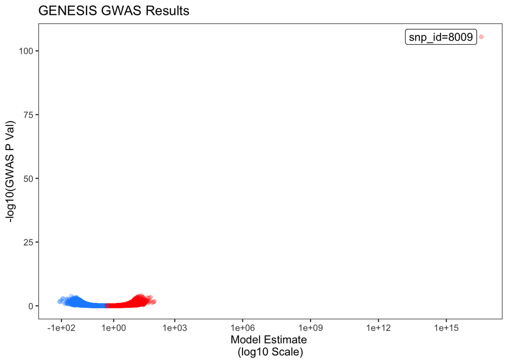

```r
# Plot Results

# Create custom log-style x axis transformer (...,-10,-3,-1,0,1,3,10,...)
custom_log_x_trans <- function(){
  trans_new("custom_log_x",
            transform = function (x) ( sign(x)*log(abs(x)+1) ),
            inverse = function (y) ( sign(y)*( exp(abs(y))-1) ),
            domain = c(-Inf,Inf))
}

# Custom log x breaker (...,-10,-3,-1,0,1,3,10,...)
custom_x_breaks <- function(x)
{
  range <- max(abs(x), na.rm=TRUE)

  return (sort( c(0,
                  sapply(0:log10(range), function(z) (10^z) ),
                  sapply(0:log10(range/3), function(z) (3*10^z) ),
                  sapply(0:log10(range), function(z) (-10^z) ),
                  sapply(0:log10(range/3), function(z) (-3*10^z) )
  )))
}

test_snp_assoc%>%
  mutate(col_group=case_when(Est>0 ~ "pos", Est<0 ~ "neg"))%>%
  mutate(plot_lab=ifelse(variant.id==snp_random$snp, paste0("snp_id=", snp_random$snp), NA))%>%
  ggplot(aes(x=Est, y=-log10(Score.pval)))+
  geom_point(alpha=0.25, aes(color=col_group))+
  ggrepel::geom_label_repel(aes(label=plot_lab))+
  scale_color_manual(values=c("pos" = "red", "neg" = "dodgerblue"), guide="none")+
  coord_trans(x="custom_log_x") +
  scale_x_continuous(breaks = custom_x_breaks(test_snp_assoc$Est)[1:length(custom_x_breaks(test_snp_assoc$Est))*6]) +
  ggtitle("GENESIS GWAS Results")+
  xlab("Model Estimate \n(log10 Scale)")+
  ylab("-log10(GWAS P Val)")+
  theme_bw()+
  theme(panel.grid = element_blank())
```

```r
# Inspect top hits
test_snp_assoc%>%
  head()%>%
  kable()%>%
  kable_styling(bootstrap_options = "striped", full_width = F)
```

| variant.id | chr | pos | n.obs | freq | MAC | Score | Score.SE | Score.Stat | Score.pval | Est | Est.SE | PVE | cov_dummy_snp |
| --- | --- | --- | --- | --- | --- | --- | --- | --- | --- | --- | --- | --- | --- |
| 8009 | 18 | 42823220 | 150 | 0.9533333 | 14 | 0.0000000 | 0.0000000 | 21.891105 | 0.0000000 | 3.527219e+16 | 1.611257e+15 | 3.2379764 | 8009 |
| 514 | 1 | 193373694 | 148 | 0.1587838 | 47 | 0.4540973 | 0.1168741 | 3.885353 | 0.0001022 | 3.324391e+01 | 8.556213e+00 | 0.1019998 | 8009 |
| 3141 | 5 | 167003466 | 149 | 0.7953020 | 61 | 0.5432259 | 0.1427346 | 3.805846 | 0.0001413 | 2.666379e+01 | 7.006009e+00 | 0.0978680 | 8009 |
| 5158 | 10 | 5124511 | 150 | 0.9000000 | 30 | -0.3949736 | 0.1042536 | -3.788584 | 0.0001515 | -3.634007e+01 | 9.591993e+00 | 0.0969822 | 8009 |
| 531 | 1 | 199204652 | 150 | 0.6900000 | 93 | 0.6003057 | 0.1630663 | 3.681359 | 0.0002320 | 2.257584e+01 | 6.132474e+00 | 0.0915703 | 8009 |
| 900 | 2 | 49703954 | 150 | 0.2266667 | 68 | 0.4650622 | 0.1275554 | 3.645963 | 0.0002664 | 2.858338e+01 | 7.839733e+00 | 0.0898179 | 8009 |

## Compare top hits to LM estimates

Compare GENESIS fits to those from standard linear model fit using lm().

```r
snp_genos<-
  getGenotype(snp_gds_sub)%>%
  as.data.frame(getSnpID(snp_gds_sub))%>%
  mutate(snpID = getSnpID(snp_gds_sub))

colnames(snp_genos)<- c(getScanID(snp_gds_sub), "snpID")


snp_genos<-
  snp_genos%>%
  mutate(snpID = paste0("snp_", snpID))%>%
  dplyr::select(snpID, everything())


# Combine with Phenotype data
pheno_meta_dummy_wSnps<-
snp_genos%>%
  column_to_rownames("snpID")%>%
  t()%>%
  as.data.frame()%>%
  rownames_to_column("scanID")%>%
  right_join(pheno_meta_dummy)%>%
  pivot_longer(contains("snp_"), names_to="snp_id", values_to = "geno")
```

```r
# Fit LM models to snps
snp_lmMod<-
  pheno_meta_dummy_wSnps%>%
  group_by(snp_id)%>%
  nest()%>%
  mutate(lmFit = map(data, ~ lm(phenotype ~ geno + cov_dummy, data = .x)),
         tidied = map(lmFit, broom::tidy))%>%
  unnest(tidied)%>%
  dplyr::select(-c(data, lmFit))
```

Compare pValues and Estimates to GENESIS results.

```r
comparison_df<-
  snp_lmMod%>%
  filter(term=="geno")%>%
  dplyr::select(snp_id, estimate, p.value)%>%
  mutate(method="LM")%>%
  bind_rows(
    test_snp_assoc%>%
      dplyr::select(variant.id, Est, Score.pval)%>%
      dplyr::rename(snp_id=variant.id, estimate=Est, p.value=Score.pval)%>%
      mutate(snp_id = paste0("snp_", snp_id), method="GENESIS")
  )%>%
  mutate(logp=-log10(p.value))%>%
  dplyr::select(-c(p.value))%>%
  pivot_longer(c(logp, estimate), names_to = "measure", values_to = "value")%>%

  pivot_wider(names_from = method, values_from = value)
```

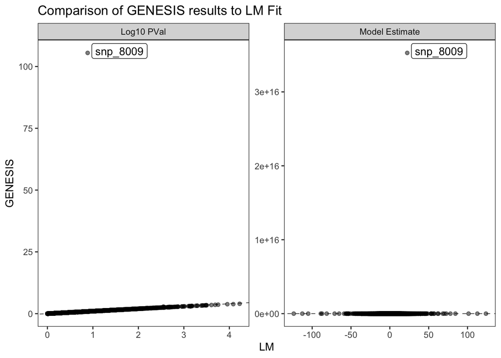

```r
# Plot comparison
comparison_df%>%
  mutate(measure = case_when(measure =="estimate" ~ "Model Estimate",
                             measure=="logp" ~ "Log10 PVal"))%>%
  mutate(plot_lab = ifelse(snp_id==paste0( "snp_", snp_random$snp), snp_id, NA))%>%
  ggplot(aes(x=LM, y=GENESIS))+
  geom_point(alpha=0.5)+
  ggrepel::geom_label_repel(aes(label=plot_lab))+
  geom_abline(slope = 1, intercept = 0, linetype="dashed", size=0.25)+
  ggtitle("Comparison of GENESIS results to LM Fit")+
  facet_wrap(~measure, scales="free")+
  theme_bw()+
  theme(panel.grid = element_blank())
```

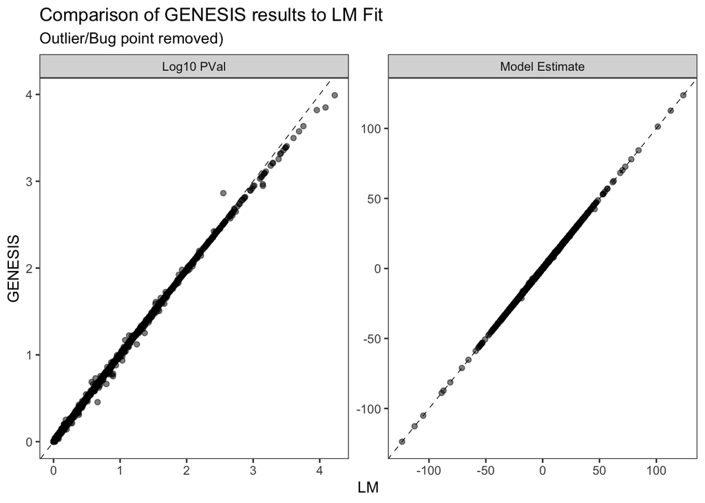

```r
# Plot comparison w/o outlier
comparison_df%>%
    mutate(measure = case_when(measure =="estimate" ~ "Model Estimate",
                             measure=="logp" ~ "Log10 PVal"))%>%
  filter(snp_id != paste0("snp_",snp_random$snp))%>%
  ggplot(aes(x=LM, y=GENESIS))+
  geom_point(alpha=0.5)+
  geom_abline(slope = 1, intercept = 0, linetype="dashed", size=0.25)+
  ggtitle("Comparison of GENESIS results to LM Fit")+
  labs(subtitle = ("Outlier/Bug point removed)"))+
  facet_wrap(~measure, scales="free")+
  theme_bw()+
  theme(panel.grid = element_blank())
```